# Load Data

```python
import pandas as pd
import numpy as np

df_Info_data = pd.read_csv('https://storage.googleapis.com/datalynn-datasets/interview-challenge/technology/Linkedin_Anomaly_Detection/InfoData.csv')
df_Info_data.head()
```

|  | user_id | profile_score | last_login | message_sent_count | message_reply_rate | feature_on | connection_count | endorsement_count | flag_count | job_post_count |
| --- | --- | --- | --- | --- | --- | --- | --- | --- | --- | --- |
| 0 | 1 | 51 | 2023-02-11 18:47:00 | 22 | 0.707707 | 0 | 94 | 13 | 0 | 1 |
| 1 | 2 | 92 | 2022-10-29 00:53:00 | 16 | 0.785362 | 0 | 93 | 3 | 0 | 0 |
| 2 | 3 | 14 | 2023-05-28 03:16:00 | 11 | 0.832910 | 0 | 104 | 19 | 0 | 0 |
| 3 | 4 | 71 | 2023-07-02 06:00:00 | 14 | 0.885132 | 0 | 112 | 33 | 0 | 1 |
| 4 | 5 | 60 | 2023-02-25 00:07:00 | 13 | 0.954988 | 0 | 89 | 11 | 1 | 1 |

# Question 1

**Data Manipulation & Cleaning**:

- **Scenario**: Given the `user_id`, `message_sent_count`, and `message_reply_rate`, can you create a SQL query that finds out which users have a suspiciously high message count but a very low reply rate, which might be an indication of spammy behavior?

## Solution

### Hints:

- Check missing values and data types in `df_Info_data`
- To identify users with suspiciously high message counts and very low reply rates, we first need to define what counts as "high" and what counts as "low"
- In this case, we define:
  - A message count is considered "high" if it's more than one standard deviation above the mean.
  - A reply rate is considered "low" if it's more than one standard deviation below the mean.

### Step 1: Data Cleaning and Manipulation

```python
# Data cleaning - Checking for missing values in query_data
print(df_Info_data.isnull().sum())

# Checking data types
print(df_Info_data.dtypes)
```

```
user_id               0
profile_score         0
last_login            0
message_sent_count    0
message_reply_rate    0
feature_on            0
connection_count      0
endorsement_count     0
flag_count            0
job_post_count        0
dtype: int64
user_id                 int64
profile_score           int64
last_login             object
message_sent_count      int64
message_reply_rate    float64
feature_on              int64
connection_count        int64
endorsement_count       int64
flag_count              int64
job_post_count          int64
dtype: object
```

### Step 2: Find the Threshold

After cleaning the data, we want to determine the threshold for 'high' message count and 'low' reply rate.

```python
# Find the mean and standard deviation of message count and reply rate
mc_mean = df_Info_data['message_sent_count'].mean()
mc_std = df_Info_data['message_sent_count'].std()

rr_mean = df_Info_data['message_reply_rate'].mean()
rr_std = df_Info_data['message_reply_rate'].std()

# Get the threholds
mc_threshold = (mc_mean + mc_std).round()
rr_threshold = (rr_mean - rr_std).round(2)

print(mc_threshold, rr_threshold)
```

```
19.0 0.76
```

### Step 3: SQL Query

```python
# Import sqlite3 to run sql on the dataframe
import sqlite3

# Establish a connection and create a database in memory (':memory:')
connect = sqlite3.connect(':memory:')

# Write the dataframe to a new database table named "my_table"
df_Info_data.to_sql('my_table', connect, if_exists='replace', index=False)

# Write the SQL query and run
query = "SELECT user_id, message_sent_count, message_reply_rate FROM my_table WHERE message_sent_count > 19 AND message_reply_rate < 0.76;"
results = pd.read_sql_query(query, connect)

print(results)
```

```
    user_id  message_sent_count  message_reply_rate
0         1                  22            0.707707
1         6                  25            0.758874
2       131                  21            0.706620
3       136                  21            0.739654
4       140                  22            0.716370
5       224                  20            0.753125
6       271                  21            0.739903
7       435                  20            0.735986
8       463                  20            0.756759
9       481                  27            0.714159
10      575                  21            0.702095
11      585                  22            0.720456
12      638                  21            0.746732
13      640                  26            0.726234
14      660                  21            0.757605
15      672                  23            0.744552
16      756                  24            0.715379
17      855                  22            0.759267
18      874                  24            0.703601
19      885                  26            0.722469
20      892                  23            0.718584
21      937                  20            0.729874
22      938                  22            0.704808
23      954                  20            0.739386
```

# Question 2

**Probability and Statistics**:

- **Scenario**: For users with a `profile_score` below the mean, find the variance of the `endorsement_count`. How does this variance relate to the likelihood of a profile being fraudulent?

## Solution

```python
# Compute mean of profile_score
mean_score = df_Info_data['profile_score'].mean()

# Filter users with profile_score below the mean and compute variance of endorsement_count
variance_endorsement = df_Info_data[df_Info_data['profile_score'] < mean_score]['endorsement_count'].var()

print(f"Variance of endorsement_count for users with profile_score below the mean: {variance_endorsement}")
```

```
Variance of endorsement_count for users with profile_score below the mean: 218.1434174796339
```

In this case, the variance of `endorsement_count` for profiles with below-average `profile_score` is high. This means there's a wide dispersion in the number of endorsements these users receive. It could imply that while many low-score profiles have few endorsements (as expected), there's a significant number with suspiciously many endorsements, which could be an indicator of fraudulent behavior (fake endorsements).

# Question 3

**Machine Learning & Modeling**:

- **Scenario**: Build a model to predict the `flag_count` for each user based on all other features, considering `flag_count` as a continuous target variable. Describe the steps you would take and the challenges you foresee in using this model for anomaly detection.
- **Target Variable**: `flag_count` (Continuous)

## Solution

### Hints

- Convert categorical variables (if any) to a format suitable for machine learning, using techniques like one-hot encoding.
- Since the target is continuous, regression models would be appropriate.
- Evaluate the model's performance on the test set using metrics suitable for regression tasks, like Mean Absolute Error (MAE), Mean Squared Error (MSE), or R-squared.
- Once the model is trained, for each user, compare the predicted flag_count with the actual value.

```python
from sklearn.model_selection import train_test_split
from sklearn.preprocessing import StandardScaler, OneHotEncoder
from sklearn.compose import ColumnTransformer
from sklearn.pipeline import Pipeline
from sklearn.ensemble import RandomForestRegressor
from sklearn.metrics import mean_squared_error

# Splitting data into train and test sets
X = df_Info_data.drop(columns=['user_id', 'flag_count','last_login'])
y = df_Info_data['flag_count']
X_train, X_test, y_train, y_test = train_test_split(X, y, test_size=0.2, random_state=42)

# Defining numeric and categorical features
numeric_features = X.select_dtypes(include=['int64', 'float64']).columns.tolist()
categorical_features = X.select_dtypes(exclude=['int64', 'float64']).columns.tolist()

# Use StandardSclar() for numerical features and OneHotEncoder for categorical features
preprocessor = ColumnTransformer(
    transformers=[
        ('num', StandardScaler(), numeric_features),
        ('cat', OneHotEncoder(), categorical_features)
    ])

# Combining the preprocessing pipline with the RandomForest Regressor as our model
pipeline = Pipeline([
    ('preprocessor', preprocessor),
    ('regressor', RandomForestRegressor(n_estimators=100))
])

# Training the model
pipeline.fit(X_train, y_train)

# Predicting on test set
y_pred = pipeline.predict(X_test)

# Evaluating the model using mean squared error
mse = mean_squared_error(y_test, y_pred)
print(f"Mean Squared Error: {mse}")
```

```
Mean Squared Error: 0.5186230000000001
```

### Challenges using this model for anomaly detection

- Assumption of Structure: Random forests assume that there's some kind of structured relationship between features and target variables. If anomalies don't fit into this structured relationship (which is often the case), the model might not be effective at detecting them.
- High Dimensionality: If there are a lot of features, the random forest might become overly complex and computationally expensive, especially when tuning hyperparameters.
- Threshold Determination: How do you determine what size of residual constitutes an anomaly? This arbitrary threshold can be tricky to define. Too strict, and you have many false alarms; too lenient, and you miss out on actual anomalies.

# Question 4

**Product Design & Analytics**:

- **Scenario**: If you were to design a dashboard for executive-level employees at LinkedIn to monitor the health and trustworthiness of the platform, which metrics from the given table would you include? Elaborate on why each metric is important.

## Solution

- Profile Score:
  - Importance: The profile score, which is based on profile completeness and activity, gives a sense of user engagement on the platform. Higher average profile scores across the platform suggest active and engaged users.
  - Visualization: A time series chart to monitor trends in average profile scores over time, combined with a distribution histogram for a snapshot view.
- Message Sent Count & Message Reply Rate:
  - Importance: A mismatch between high message counts and low reply rates could indicate spammy behavior. It's essential to ensure users aren't being inundated with spam or low-quality messages.
  - Visualization: A scatter plot with message sent count on the x-axis and reply rate on the y-axis. Points clustered in the high message count but low reply rate zone are areas of concern.
- Flag Count:
  - Importance: A high flag count can indicate distrustful or spammy behavior. Monitoring spikes or trends in this metric can help take preemptive actions to maintain platform integrity.

  -Visualization: Time series chart of daily/weekly flag counts. Highlighting users with extraordinarily high flags can also be beneficial.

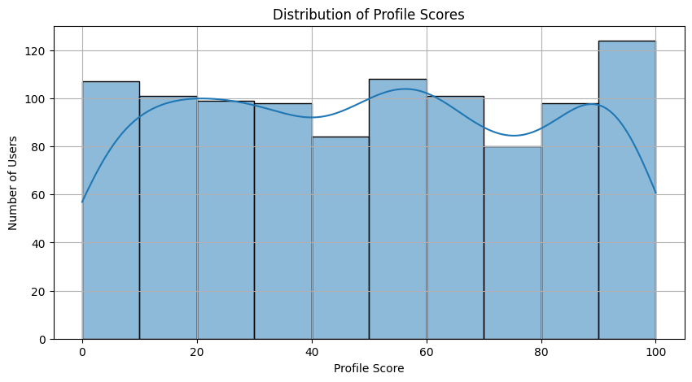

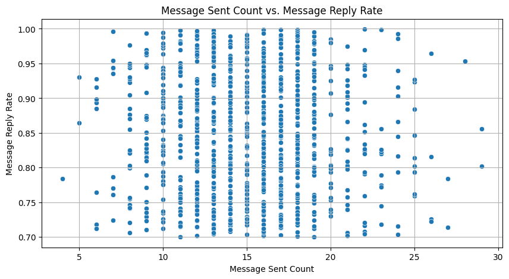

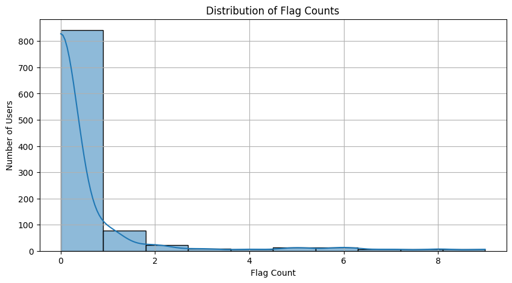

```python
import matplotlib.pyplot as plt
import seaborn as sns

# Visualization for Profile Score
plt.figure(figsize=(10, 5))
sns.histplot(df_Info_data['profile_score'], bins=10, kde=True)
plt.title("Distribution of Profile Scores")
plt.xlabel("Profile Score")
plt.ylabel("Number of Users")
plt.grid(True)
plt.show()

# Visualization for Message Sent Count vs. Message Reply Rate
plt.figure(figsize=(10, 5))
sns.scatterplot(x='message_sent_count', y='message_reply_rate', data=df_Info_data)
plt.title("Message Sent Count vs. Message Reply Rate")
plt.xlabel("Message Sent Count")
plt.ylabel("Message Reply Rate")
plt.grid(True)
plt.show()

# Visualization for Flag Count
plt.figure(figsize=(10, 5))
sns.histplot(df_Info_data['flag_count'], bins=10, kde=True)
plt.title("Distribution of Flag Counts")
plt.xlabel("Flag Count")
plt.ylabel("Number of Users")
plt.grid(True)
plt.show()
```